# Standard binomial logistic regression is a 2PL — `mid` is implicit, not free

Author

Daniel W.A. Noble (clarification dialogue with Claude)

Published

May 7, 2026

## Question

A standard binomial regression (logistic model) `glm(cbind(dead, alive) ~ log10(time), family = binomial)` only fits a slope and intercept. So is that a 2PL? And if so, where does the curve midpoint `mid` live, given it’s not estimated as a separate parameter?

## Short answer

**Yes — a binomial GLM with logit link and one continuous predictor is a 2PL** (2-parameter logistic). The asymptotes $\ell=0$ and $u=1$ are pinned by the link function, leaving only the steepness $k$ and midpoint $\text{mid}$ free. They are encoded in the slope and intercept of the linear predictor as

$$k \;=\; -\beta_1, \qquad \mathrm{mid} \;=\; -\beta_0 / \beta_1.
\tag{1}$$

So `mid` is *not* a separate free parameter in the GLM — it’s the ratio of intercept to negative slope, hiding in the same fit.

## Algebra: 4PL ↔︎ logit GLM

Start with the 4PL with asymptotes pinned at $(\ell, u) = (0, 1)$:

$$S(\tau) \;=\; \frac{1}{1 + \exp\!\big(k\,(\log_{10}\tau - \mathrm{mid})\big)}.$$

Apply the logit transformation:

$$\mathrm{logit}(S) \;=\; \log\!\frac{S}{1 - S} \;=\; -k\,(\log_{10}\tau - \mathrm{mid}) \;=\; k\,\mathrm{mid} \;-\; k\,\log_{10}\tau.$$

This is linear in $\log_{10}\tau$. Matching to a logit-binomial GLM,

$$\mathrm{logit}(S) \;=\; \beta_0 \;+\; \beta_1 \log_{10}\tau,$$

gives the 2PL ↔︎ GLM mapping:

$$\beta_0 \;=\; k\,\mathrm{mid}, \qquad \beta_1 \;=\; -k.$$

Inverting:

$$k \;=\; -\beta_1, \qquad \mathrm{mid} \;=\; -\beta_0/\beta_1.$$

The midpoint $\mathrm{mid}$ — i.e. $\log_{10}(LT_{50})$ — falls out as the *intercept-to-slope ratio*, with a sign flip. Setting $S = 0.5$ confirms this directly: $\mathrm{logit}(0.5) = 0$, so $0 = \beta_0 + \beta_1 \cdot \mathrm{mid}$, giving $\mathrm{mid} = -\beta_0/\beta_1$.

## Why GLM users don’t usually think of `mid` as a parameter

A GLM is fit on the linear-predictor scale: you estimate $(\beta_0, \beta_1)$, those are what `summary(fit)` reports, and `mid` doesn’t appear in the output. But the curve’s midpoint is fully determined the moment $(\beta_0, \beta_1)$ are estimated — it’s just a derived quantity. To get $LT_{50}$ from a GLM:

```r
fit  <- glm(cbind(dead, alive) ~ log10(time), family = binomial(link = "logit"))
b0   <- coef(fit)[1]
b1   <- coef(fit)[2]
mid  <- -b0 / b1                # log10(LT50)
LT50 <- 10 ^ mid                # back to the time scale
```

Equivalently, the `MASS::dose.p()` function in R computes $LT_{50}$ (or any $LT_x$) from a binomial GLM fit by exactly this inversion.

## When the 2PL is enough vs when you actually need the 4PL

Use the **2PL (logit-binomial GLM)** when:

- Baseline mortality is effectively zero — i.e. essentially every organism is alive at very short exposures.
- No irreducible-survivor plateau — i.e. essentially all organisms eventually die under prolonged extreme heat in the assay.
- Data span enough of the dose-response that asymptote behaviour is well-pinned by the data (you’re not extrapolating into uncovered regions).

Use the **full 4PL** when:

- Some baseline mortality exists (handling stress, controls aren’t perfect) → $u < 1$.
- A fraction of the population is irreducibly resistant or the assay can’t kill everyone in a tractable timeframe → $\ell > 0$.
- Data are sparse near the asymptotes and the asymptote values matter for downstream quantities like $LT_{50}$ and $z$.

## Worked simulation: GLM and 4PL recover the same $k$ and `mid`

```r
library(ggplot2)
library(dplyr)

set.seed(20260507)

# True 4PL parameters (with asymptotes 0 and 1 so the GLM is well-specified)
ell_true <- 0
u_true   <- 1
k_true   <- 4
mid_true <- log10(60)

# Generate binomial data at a range of times
time_min <- c(5, 10, 15, 20, 30, 45, 60, 90, 120, 180, 240, 360)
n_per    <- 50
S_true   <- ell_true + (u_true - ell_true) / (1 + exp(k_true * (log10(time_min) - mid_true)))
dead     <- rbinom(length(time_min), size = n_per, prob = 1 - S_true)
alive    <- n_per - dead

# Standard binomial GLM (the 2PL fit)
fit_glm <- glm(cbind(alive, dead) ~ log10(time_min), family = binomial(link = "logit"))
b0      <- coef(fit_glm)[1]
b1      <- coef(fit_glm)[2]
k_hat   <- -b1
mid_hat <- -b0 / b1

sprintf("True parameters:    k = %.3f, mid = %.3f (LT50 = %.1f min)",
        k_true, mid_true, 10^mid_true)
```

```
[1] "True parameters:    k = 4.000, mid = 1.778 (LT50 = 60.0 min)"
```

```r
sprintf("GLM-recovered:      k = %.3f, mid = %.3f (LT50 = %.1f min)",
        k_hat, mid_hat, 10^mid_hat)
```

```
[1] "GLM-recovered:      k = 4.322, mid = 1.765 (LT50 = 58.2 min)"
```

```r
sprintf("β0 = %.3f, β1 = %.3f", b0, b1)
```

```
[1] "β0 = 7.629, β1 = -4.322"
```

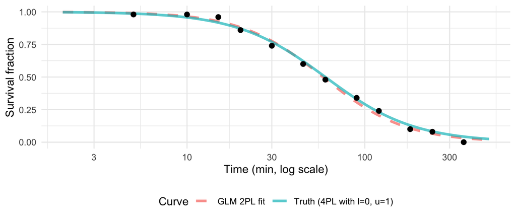

Figure 1: Simulated binomial-survival data (points) at 12 time points, with the true 4PL curve (solid) and the GLM 2PL fit (dashed). The two curves are visually indistinguishable when the asymptotes are 0 and 1 — confirming the 2PL is the GLM with $\ell, u$ pinned, and `mid` recoverable from $-\beta_0/\beta_1$.

```r
t_grid <- 10 ^ seq(log10(2), log10(500), length.out = 200)
S_truth <- ell_true + (u_true - ell_true) / (1 + exp(k_true * (log10(t_grid) - mid_true)))
S_glm   <- 1 / (1 + exp(-(b0 + b1 * log10(t_grid))))

df_curves <- tibble(
  time_min = rep(t_grid, 2),
  S        = c(S_truth, S_glm),
  Curve    = rep(c("Truth (4PL with l=0, u=1)", "GLM 2PL fit"), each = length(t_grid))
)
df_data <- tibble(time_min = time_min,
                  S = alive / (alive + dead))

ggplot() +
  geom_line(data = df_curves,
            aes(time_min, S, colour = Curve, linetype = Curve),
            linewidth = 1.2, alpha = 0.7) +
  geom_point(data = df_data, aes(time_min, S),
             colour = "black", size = 2) +
  scale_x_log10() +
  scale_linetype_manual(values = c("dashed", "solid")) +
  labs(x = "Time (min, log scale)", y = "Survival fraction") +
  theme_minimal(base_size = 11) +
  theme(legend.position = "bottom")
```

The simulation confirms the algebraic mapping: the 2PL GLM recovers the true $k$ and `mid` (and hence $LT_{50}$) of a 4PL with $\ell=0, u=1$ to within sampling noise.

## Implications for the manuscript

- The two-stage TDT pipeline as practised in the literature (Jørgensen *et al.* 2019; Rezende *et al.* 2014) typically uses a 2PL (logit binomial GLM) at Stage 1 to extract $LT_{50}$ at each temperature, then OLS regresses $\log_{10}(LT_{50})$ on $T$ at Stage 2 to extract $z$ and $CT_{max}$. The 2PL is hardcoded into Stage 1 — there’s no asymptote estimation; the model assumes $\ell = 0, u = 1$.
- The joint Bayesian 4PL relaxes this assumption by estimating $\ell$ and $u$ as parameters with informative priors. When the data are consistent with $\ell \approx 0, u \approx 1$, the 4PL collapses to a 2PL and the two methods give identical $k$, `mid`, $LT_{50}$. When the data show baseline mortality or irreducible survivors, the 4PL captures it; the 2PL would force the curve to pass through 0 and 1 and produce biased $LT_{50}$ estimates.
- This is one specific instance of the general “the joint Bayesian 4PL collapses to the two-stage approach in benign data, but adds robustness in non-benign data” framing that runs through the manuscript.

## References

Jørgensen, L.B., Malte, H. & Overgaard, J. (2019). [How to assess Drosophila heat tolerance: Unifying static and dynamic tolerance assays to predict heat distribution limits](https://doi.org/10.1111/1365-2435.13279). *Functional Ecology*, 33, 629–642.

Rezende, E.L., Castañeda, L.E. & Santos, M. (2014). [Tolerance landscapes in thermal ecology](https://doi.org/10.1111/1365-2435.12268). *Functional Ecology*, 28, 799–809.